# The Relationship between Urban Green Space and Socioeconomic Factors in the City of Vancouver, A Case of Environmental Injustice

Daina De Angelis

Jill Mezenberg

Maeve Nowitsky

Tim Truong

21/4/2023

```r
# Clearing data
rm(list = ls())
```

```r
# loading packages
library(cancensus) #this package allows us to download census data from Stats Canada
library(ggplot2)
library(tidyverse) #collection of packages for data visualization and manipulation (includes dplyr and ggplot2)
library(tidycensus)
library(tigris)
library(kableExtra)
library(plotly)
library(sf)
library(spatialreg)
library(spdep)
library(spgwr)
library(dplyr)
library(r5r)
library(rJava)
library(cartogram)
library(kableExtra)
library(plotly) #packaged used to create interactive graphics
library(sf) #package to work with geospatial data of simple feature class
library(spatialreg) #package used to perform spatial regression analysis
library(spdep) #package used to compute spatial dependence, weighting schemes, and spatial statistics
library(spgwr) # package for geographically weighted regression
library(dplyr) #package to work with and manipulate data frames
library(r5r) #package to generate routing analysis and calculate the accessibility of parks in Vancouver
library(rJava) #an r to java interface used to support the r5r package
library(stargazer) #package to show results of regression analysis as a table
```

#Study Area This study took place at the Census Subdivision level to target the municipality of Vancouver, BC. There are 127 census tracts in Vancouver that were studied.

```r
# storing the API key in system environment to be easily used in API calls
options(cancensus.api_key = "CensusMapper_ff4c917e80df34b71900e0a048c999dd")
```

```r
# assigning a persistent local cache
options(cancensus.cache_path = "/Users/dainadeangelis/Desktop/4GA3Project-/Project data")
Sys.setenv(CM_CACHE_PATH = "/Users/dainadeangelis/Desktop/4GA3Project-/Project data")
```

```r
# returning census data and geography for the Vancouver CMA as an sf-class dataframe
census_data <- get_census(dataset='CA21', regions=list(CSD="5915022"), vectors=c("v_CA21_1","v_CA21_386","v_CA21_906", "v_CA21_4875", "v_CA21_4914", "v_CA21_1010"), labels="detailed", geo_format="sf", level='CT')
```

```
## Reading vectors data from local cache.
```

```
## Reading geo data from local cache.
```

```r
# removing columns that are not needed for analysis
census_data <- census_data[,-c(4,5,9,10,13,15,16)]
```

```r
# renaming the columns in the dataset
names(census_data) [1] <- "Shape_area_km2"
names(census_data) [3] <- "Number_of_households"
names(census_data) [4] <- "Region_name"
names(census_data) [7] <- "Number_of_dwellings"
names(census_data) [10:15] <- c("Population_2021", "Average_age", "Median_total_income_of_household_2020", "Total_visible_minority_population", "Not_a_visible_minority", "Low_income_status_for_the_population_in_private_households_2020")
```

#Data The data used for analysis includes census data for variables of population, population density, visible minority status, non-visible minority status, and income for each census tract in the census subdivision of Vancouver. This data was obtained from Statistics Canada through use of the cancensus package in R. All census data used is from the 2021 census. Point data for each the location of each park, homeless shelter, and street tree in the census subdivision was downloaded in a .csv file format from the City of Vancouver’s open data portal. To use the r5r package so that accessibility to parks by both walking and public transit could be determined, a road network dataset of Vancouver, and as well as a public transport feed of the city was needed. The road network dataset was obtained from BBBike, and was stored as a .pbf file. The public transport feed was obtained from Transitland and stored in a GTFS.zip file.

#Methods To determine the relationship between greenspace and other socioeconomic factors in Vancouver, Rstudio was used to analyze and visualize the variables being examined. Choropleth maps for variables of population, population density, visible minority status, non-visible minority status, and income, and accessibility to parks were made to provide a visual representation of the difference between census tracts. Regression analysis was used to determine the relationship between the independent variable studied (number of parks accessible within a 30 minute travel time) and dependent variables (population, population density, visible minority status, non-visible minority status, and income). Scatterplots were used to show a visual representation between independent and dependent variables studied to better understand the results of regression analysis.

#Results

To begin our analysis, the centroids for each census tract in the Vancouver CSD were obtained and put into a dataframe with latitude, longitude, and census ID. This allowed us to have point data describing the middle of each CT.

```r
# obtaining centroids for census tracts in the Vancouver CSD
CT_centroids <- st_coordinates(st_centroid(census_data))
#converting centroids to data frame
centroids_df <- as.data.frame(CT_centroids)
class(centroids_df)
```

```
## [1] "data.frame"
```

```r
centroids_df<- cbind(centroids_df, census_data$GeoUID)

centroids_df <- centroids_df %>%
                    rename("lon" = "X",
                           "lat" = "Y",
                           "id" = "census_data$GeoUID")
```

```r
# calculating population density for the census tracts in Vancouver
census_data <- census_data %>%
  mutate(Population_density =
           (Population_2021 / Shape_area_km2))
```

```r
# calculating the proportion of the minority population and adding to census_data
census_data <- census_data %>%
  mutate(Proportion_visible_minority= (Total_visible_minority_population / Population_2021))
```

```r
# calculating the proportion of the non visible minority population and adding to census_data
census_data <- census_data %>%
  mutate(Proportion_nonvisible_minority= (Not_a_visible_minority / Population_2021))
```

```r
# calculating the proportion of low income status in Vancouver census tracts
census_data <- census_data %>%
  mutate(Proportion_low_income = (Low_income_status_for_the_population_in_private_households_2020 / Population_2021))
```

The point data for park in the Vancouver CSD was obtained from a csv file from Vancouver’s open data portal and transformed into a data frame with columns describing the X and Y coordinates of each park.

```r
# reading csv files
parks <- read.csv(file = "Project data/parks.csv", head = TRUE, sep = ";")
```

```r
#extracting point data from park csv file
parks_coord <- data.frame(do.call("rbind", strsplit(as.character(parks$GoogleMapDest), ",", fixed = TRUE)))

# Rename multiple columns
parks_coord <- parks_coord %>%
                    rename("X" = "X1",
                           "Y" = "X2")
```

The point data for parks was prepared for use of the r5r package by renaming coulumns for latitude, longitude, and park ID data and to the names required by r5r. Data for latitude and longitude was converted into a numeric format. Lastly, a column to indicate that each park point was one singular park was added to meet the requirement of the opportunites parameter in r5r.

```r
#preparing park data for r5r
class(parks_coord)
```

```
## [1] "data.frame"
```

```r
parks_coord<- cbind(parks_coord, parks$ParkID)

# renaming columns
parks_coord <- parks_coord %>%
                   rename("lat" = "X",
                          "lon" = "Y",
                          "id" = "parks$ParkID")

# changing columns to numeric
parks_coord$lon <- as.numeric(parks_coord$lon)
parks_coord$lat <- as.numeric(parks_coord$lat)
```

```r
parks_coord <- parks_coord %>%
  add_column(Parks_count = 1)
```

Next, the r5r package was used in order to build a transport network for Vancouver, so that the distances and routing between the centroids of census tracts and park locations can be calculated.

```r
#allocating RAM memory to Java to use the r5r package
options(java.parameters = "-Xmx2G")
```

The transport network was built with using a road network dataset of Vancouver, and as well as a public transport feed of the city. The road network dataset was obtained from BBBike, and was stored as a .pbf file. The public transport feed was obtained from Transitland and stored in a GTFS.zip file.

```r
#building transport network for r5r
path <- file.path("Project data/r5rpath")

#building transport network for r5r
list.files(path)
```

```
## [1] "GTFS_TRANIST.zip"          "network_settings.json"
## [3] "network.dat"               "Vancouver.osm.pbf"
## [5] "Vancouver.osm.pbf.mapdb"   "Vancouver.osm.pbf.mapdb.p"
```

```r
r5r_core <- setup_r5(data_path = path)
```

```
## No raster .tif files found. Using elevation = 'NONE'.
```

```
## Using cached R5 version from /Library/Frameworks/R.framework/Versions/4.2/Resources/library/r5r/jar/r5-v6.9-all.jar
```

```
##
## Using cached network.dat from Project data/r5rpath/network.dat
```

```r
#load origin points as the centroids of census tracts
points <- centroids_df
class(points)
```

```
## [1] "data.frame"
```

```r
#points of interest: parks
poi <- parks_coord
#departure times
departure_datetime <- as.POSIXct("16-02-2023 14:00:00",
                                 format = "%d-%m-%Y %H:%M:%S")
```

The accessibility function in r5r was used to compute how many parks were accessible within 30 minutes of each census tracts centroid by walking or public transit.

```r
#using accessibility from r5r
access <- accessibility(r5r_core = r5r_core,
                        origins = points,
                        destinations = poi,
                        opportunities_colnames = c("Parks_count"),
                        mode = c("WALK", "TRANSIT"),
                        departure_datetime = departure_datetime,
                        decay_function = "step",
                        cutoffs = 30)
```

Once the number of accessible parks was calculated, this was added to the data frame displaying census data.

```r
census_data <- cbind(census_data, accessibility = access$accessibility)
```

After all variables were in one data frame and prepared for analysis, data was first visualized by creating choropleth maps for each variable of interest. Maps were created for each variable as follows:

Population of each CT

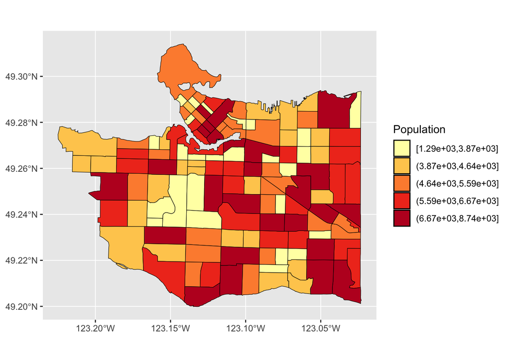

```r
# creating a choropleth map for the 2021 population
ggplot(census_data) +
  geom_sf(aes(fill = cut_number(Population_2021, 5)),
          colour = "black",
          size = 0.1) +
  scale_fill_brewer(palette = "YlOrRd") +
  coord_sf() +
  labs(fill = "Population")
```

Population density of each CT

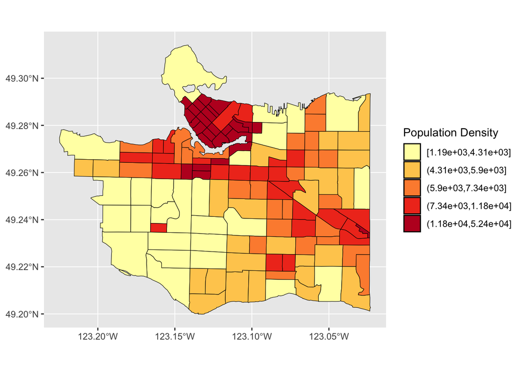

```r
# creating a choropleth map for the population density
ggplot(census_data) +
  geom_sf(aes(fill = cut_number(Population_density, 5)),
          colour = "black",
          size = 0.1) +
  scale_fill_brewer(palette = "YlOrRd") +
  coord_sf() +
  labs(fill = "Population Density")
```

Proportion of population identifying as visible and non-visible minorities

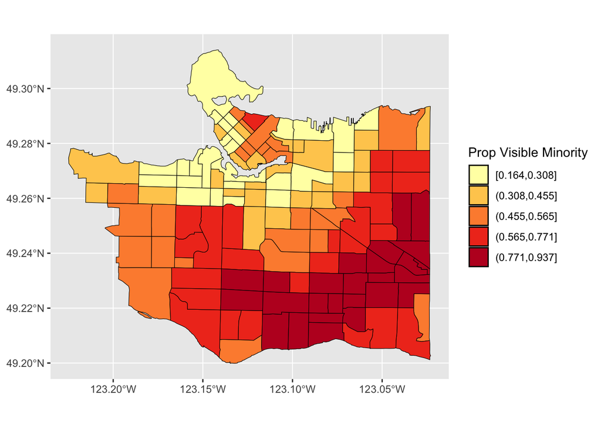

```r
# creating a choropleth map for the proportion of the visisble minority population
ggplot(census_data) +
geom_sf(aes(fill = cut_number(Proportion_visible_minority, 5)),
        color = "black",
        size = 0.1) +
scale_fill_brewer(palette = "YlOrRd") +
labs(fill = "Prop Visible Minority")
```

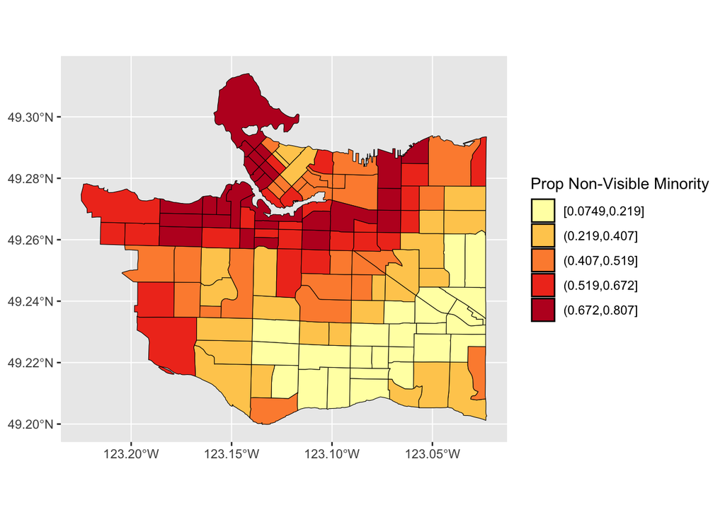

```r
# creating a choropleth map for the proportion of the non-visible minority population
ggplot(census_data) +
geom_sf(aes(fill = cut_number(Proportion_nonvisible_minority, 5)),
        color = "black",
        size = 0.1) +
scale_fill_brewer(palette = "YlOrRd") +
labs(fill = "Prop Non-Visible Minority")
```

The proportion of the population considered low income for each CT

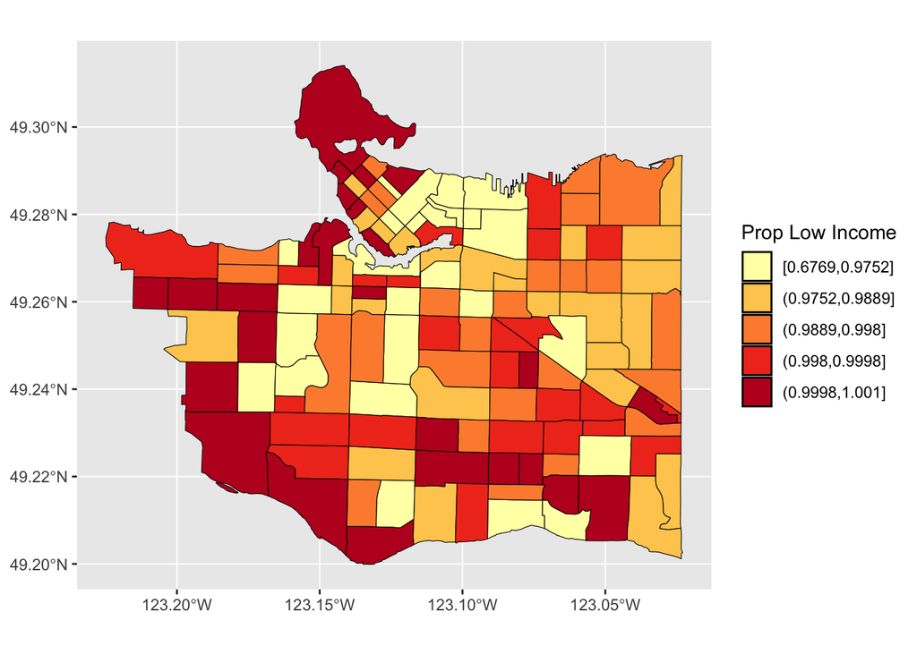

```r
# creating a choropleth map displaying the proportion of low-income
ggplot(census_data) +
geom_sf(aes(fill = cut_number(Proportion_low_income, 5)),
        color = "black",
        size = 0.1) +
scale_fill_brewer(palette = "YlOrRd") +
labs(fill = "Prop Low Income")
```

Finally, a choropleth map was created to display the independent variable, parks accessible within 30 mintues of a centroid.

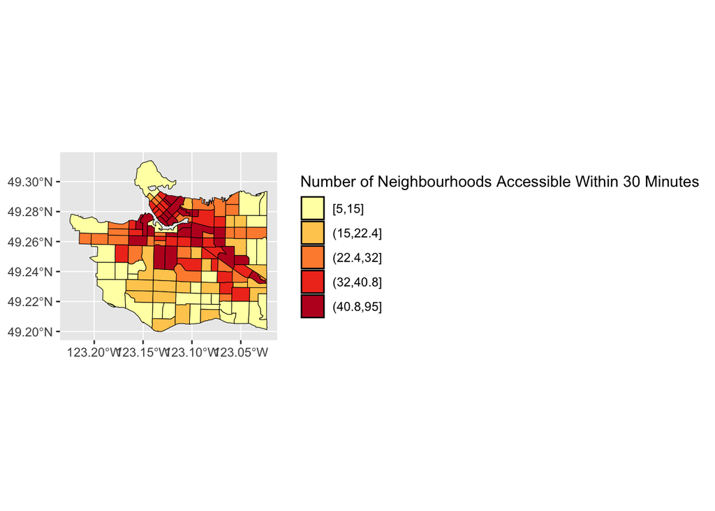

```r
# creating a choropleth map displaying the number of parks accessible to a census tract's centroids within 30 minutes
ggplot(census_data) +
geom_sf(aes(fill = cut_number(accessibility, 5)),
        color = "black",
        size = 0.1) +
scale_fill_brewer(palette = "YlOrRd") +
labs(fill = "Number of Neighbourhoods Accessible Within 30 Minutes")
```

Next, to determine the relationship between the number of accessible parks and each independent variable, the independent variables were regressed to number of accessible parks for each CT.

```r
#creating a regression model of population regressing on number of accessible parks
model_population <- lm(formula = Population_2021 ~ accessibility,
             data = census_data)

stargazer(model_population,
          header = FALSE,
          title = "Population of Census Tracts regressed on Number of Parks Accessible")
```

```
##
## \begin{table}[!htbp] \centering
##   \caption{Population of Census Tracts regressed on Number of Parks Accessible}
##   \label{}
## \begin{tabular}{@{\extracolsep{5pt}}lc}
## \\[-1.8ex]\hline
## \hline \\[-1.8ex]
##  & \multicolumn{1}{c}{\textit{Dependent variable:}} \\
## \cline{2-2}
## \\[-1.8ex] & Population\_2021 \\
## \hline \\[-1.8ex]
##  accessibility & 10.518 \\
##   & (7.816) \\
##   & \\
##  Constant & 4,904.639$^{***}$ \\
##   & (264.208) \\
##   & \\
## \hline \\[-1.8ex]
## Observations & 127 \\
## R$^{2}$ & 0.014 \\
## Adjusted R$^{2}$ & 0.006 \\
## Residual Std. Error & 1,459.451 (df = 125) \\
## F Statistic & 1.811 (df = 1; 125) \\
## \hline
## \hline \\[-1.8ex]
## \textit{Note:}  & \multicolumn{1}{r}{$^{*}$p$<$0.1; $^{**}$p$<$0.05; $^{***}$p$<$0.01} \\
## \end{tabular}
## \end{table}
```

```r
summary(model_population)
```

```
##
## Call:
## lm(formula = Population_2021 ~ accessibility, data = census_data)
##
## Residuals:
##     Min      1Q  Median      3Q     Max
## -4118.5 -1065.2  -159.5  1192.0  3319.0
##
## Coefficients:
##               Estimate Std. Error t value Pr(>|t|)
## (Intercept)   4904.639    264.208  18.564   <2e-16 ***
## accessibility   10.518      7.816   1.346    0.181
## ---
## Signif. codes:  0 '***' 0.001 '**' 0.01 '*' 0.05 '.' 0.1 ' ' 1
##
## Residual standard error: 1459 on 125 degrees of freedom
## Multiple R-squared:  0.01428,    Adjusted R-squared:  0.006395
## F-statistic: 1.811 on 1 and 125 DF,  p-value: 0.1808
```

For each regression, a scatter plot was created to provide a visual representation of the data

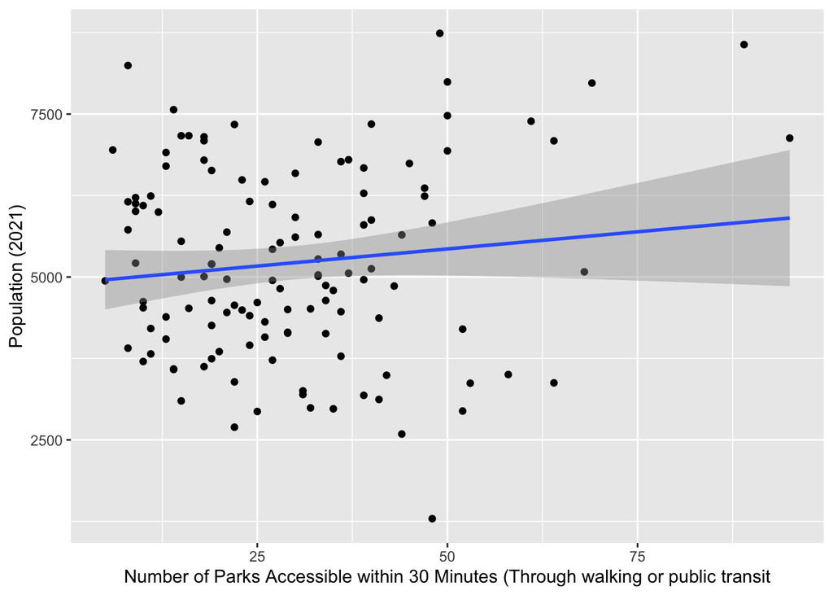

```r
ggplot(data = census_data,
       aes(x = accessibility,
           y = Population_2021))+
  geom_point() +
  geom_smooth(formula = y ~ x,
              method = "lm") +
  ylab("Population (2021)") +
  xlab("Number of Parks Accessible within 30 Minutes (Through walking or public transit")
```

Model regressing population density on number of accessible marks

```r
#creating a regression model of population density regressing on number of accessible parks
model_population_density <- lm(formula = Population_density ~ accessibility,
             data = census_data)

stargazer(model_population_density,
          header = FALSE,
          title = "Population Density of Census Tracts regressed on Number of Parks Accessible")
```

```
##
## \begin{table}[!htbp] \centering
##   \caption{Population Density of Census Tracts regressed on Number of Parks Accessible}
##   \label{}
## \begin{tabular}{@{\extracolsep{5pt}}lc}
## \\[-1.8ex]\hline
## \hline \\[-1.8ex]
##  & \multicolumn{1}{c}{\textit{Dependent variable:}} \\
## \cline{2-2}
## \\[-1.8ex] & Population\_density \\
## \hline \\[-1.8ex]
##  accessibility & 215.382$^{***}$ \\
##   & (39.775) \\
##   & \\
##  Constant & 2,995.220$^{**}$ \\
##   & (1,344.555) \\
##   & \\
## \hline \\[-1.8ex]
## Observations & 127 \\
## R$^{2}$ & 0.190 \\
## Adjusted R$^{2}$ & 0.184 \\
## Residual Std. Error & 7,427.142 (df = 125) \\
## F Statistic & 29.322$^{***}$ (df = 1; 125) \\
## \hline
## \hline \\[-1.8ex]
## \textit{Note:}  & \multicolumn{1}{r}{$^{*}$p$<$0.1; $^{**}$p$<$0.05; $^{***}$p$<$0.01} \\
## \end{tabular}
## \end{table}
```

```r
summary(model_population_density)
```

```
##
## Call:
## lm(formula = Population_density ~ accessibility, data = census_data)
##
## Residuals:
##    Min     1Q Median     3Q    Max
## -12200  -3462  -1687    715  44466
##
## Coefficients:
##               Estimate Std. Error t value Pr(>|t|)
## (Intercept)    2995.22    1344.55   2.228   0.0277 *
## accessibility   215.38      39.78   5.415 3.02e-07 ***
## ---
## Signif. codes:  0 '***' 0.001 '**' 0.01 '*' 0.05 '.' 0.1 ' ' 1
##
## Residual standard error: 7427 on 125 degrees of freedom
## Multiple R-squared:   0.19,  Adjusted R-squared:  0.1835
## F-statistic: 29.32 on 1 and 125 DF,  p-value: 3.018e-07
```

Scatterplot of population density vs number of accessible parks

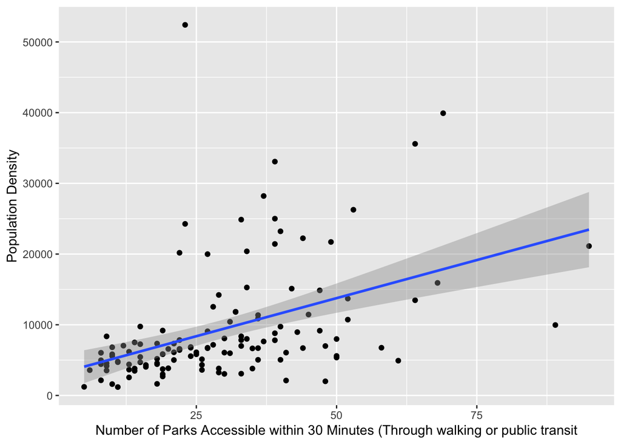

```r
ggplot(data = census_data,
       aes(x = accessibility,
           y = Population_density))+
  geom_point() +
  geom_smooth(formula = y ~ x,
              method = "lm") +
  ylab("Population Density") +
  xlab("Number of Parks Accessible within 30 Minutes (Through walking or public transit")
```

Model regressing proportion of visible minorities on number of accessible parks

```r
#creating a regression model of population density regressing on number of accessible parks
model_visible_minority <- lm(formula = Proportion_visible_minority ~ accessibility,
             data = census_data)

stargazer(model_visible_minority,
          header = FALSE,
          title = "Proportion of Visible Minority Population in Census Tracts regressed on Number of Parks Accessible")
```

```
##
## \begin{table}[!htbp] \centering
##   \caption{Proportion of Visible Minority Population in Census Tracts regressed on Number of Parks Accessible}
##   \label{}
## \begin{tabular}{@{\extracolsep{5pt}}lc}
## \\[-1.8ex]\hline
## \hline \\[-1.8ex]
##  & \multicolumn{1}{c}{\textit{Dependent variable:}} \\
## \cline{2-2}
## \\[-1.8ex] & Proportion\_visible\_minority \\
## \hline \\[-1.8ex]
##  accessibility & $-$0.004$^{***}$ \\
##   & (0.001) \\
##   & \\
##  Constant & 0.654$^{***}$ \\
##   & (0.037) \\
##   & \\
## \hline \\[-1.8ex]
## Observations & 127 \\
## R$^{2}$ & 0.110 \\
## Adjusted R$^{2}$ & 0.103 \\
## Residual Std. Error & 0.205 (df = 125) \\
## F Statistic & 15.511$^{***}$ (df = 1; 125) \\
## \hline
## \hline \\[-1.8ex]
## \textit{Note:}  & \multicolumn{1}{r}{$^{*}$p$<$0.1; $^{**}$p$<$0.05; $^{***}$p$<$0.01} \\
## \end{tabular}
## \end{table}
```

```r
summary(model_visible_minority)
```

```
##
## Call:
## lm(formula = Proportion_visible_minority ~ accessibility, data = census_data)
##
## Residuals:
##      Min       1Q   Median       3Q      Max
## -0.41644 -0.15748  0.00557  0.18028  0.37338
##
## Coefficients:
##                Estimate Std. Error t value Pr(>|t|)
## (Intercept)    0.654239   0.037080  17.644  < 2e-16 ***
## accessibility -0.004320   0.001097  -3.938 0.000135 ***
## ---
## Signif. codes:  0 '***' 0.001 '**' 0.01 '*' 0.05 '.' 0.1 ' ' 1
##
## Residual standard error: 0.2048 on 125 degrees of freedom
## Multiple R-squared:  0.1104, Adjusted R-squared:  0.1033
## F-statistic: 15.51 on 1 and 125 DF,  p-value: 0.0001355
```

Scatterplot of proportion of visible minorities vs number of accessible parks

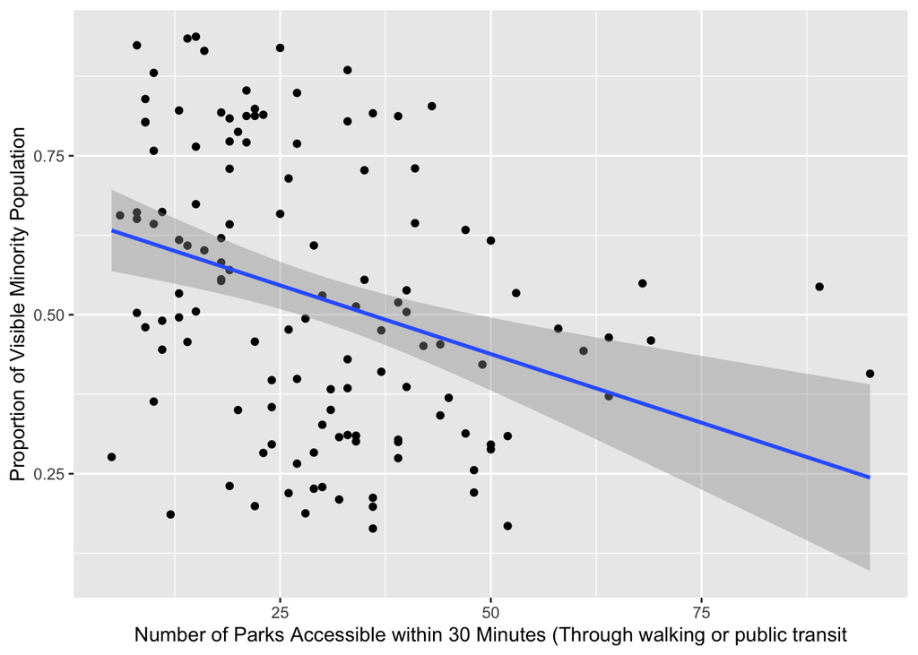

```r
ggplot(data = census_data,
       aes(x = accessibility,
           y = Proportion_visible_minority))+
  geom_point() +
  geom_smooth(formula = y ~ x,
              method = "lm") +
  ylab("Proportion of Visible Minority Population") +
  xlab("Number of Parks Accessible within 30 Minutes (Through walking or public transit")
```

Model regressing proportion of non-visible minorities on number of accessible parks

```r
#creating a regression model of population density regressing on number of accessible parks
model_nonvisible_minority <- lm(formula = Proportion_nonvisible_minority ~ accessibility,
             data = census_data)

stargazer(model_nonvisible_minority,
          header = FALSE,
          title = "Proportion of Non-Visible Minority Population in Census Tracts regressed on Number of Parks Accessible")
```

```
##
## \begin{table}[!htbp] \centering
##   \caption{Proportion of Non-Visible Minority Population in Census Tracts regressed on Number of Parks Accessible}
##   \label{}
## \begin{tabular}{@{\extracolsep{5pt}}lc}
## \\[-1.8ex]\hline
## \hline \\[-1.8ex]
##  & \multicolumn{1}{c}{\textit{Dependent variable:}} \\
## \cline{2-2}
## \\[-1.8ex] & Proportion\_nonvisible\_minority \\
## \hline \\[-1.8ex]
##  accessibility & 0.004$^{***}$ \\
##   & (0.001) \\
##   & \\
##  Constant & 0.336$^{***}$ \\
##   & (0.037) \\
##   & \\
## \hline \\[-1.8ex]
## Observations & 127 \\
## R$^{2}$ & 0.097 \\
## Adjusted R$^{2}$ & 0.090 \\
## Residual Std. Error & 0.203 (df = 125) \\
## F Statistic & 13.473$^{***}$ (df = 1; 125) \\
## \hline
## \hline \\[-1.8ex]
## \textit{Note:}  & \multicolumn{1}{r}{$^{*}$p$<$0.1; $^{**}$p$<$0.05; $^{***}$p$<$0.01} \\
## \end{tabular}
## \end{table}
```

```r
summary(model_nonvisible_minority)
```

```
##
## Call:
## lm(formula = Proportion_nonvisible_minority ~ accessibility,
##     data = census_data)
##
## Residuals:
##      Min       1Q   Median       3Q      Max
## -0.36102 -0.18133 -0.00251  0.16906  0.39551
##
## Coefficients:
##               Estimate Std. Error t value Pr(>|t|)
## (Intercept)   0.336380   0.036681   9.170  1.2e-15 ***
## accessibility 0.003983   0.001085   3.671 0.000357 ***
## ---
## Signif. codes:  0 '***' 0.001 '**' 0.01 '*' 0.05 '.' 0.1 ' ' 1
##
## Residual standard error: 0.2026 on 125 degrees of freedom
## Multiple R-squared:  0.0973, Adjusted R-squared:  0.09007
## F-statistic: 13.47 on 1 and 125 DF,  p-value: 0.0003571
```

Scatterplot of proportion of non-visible minorities vs number of accessible parks

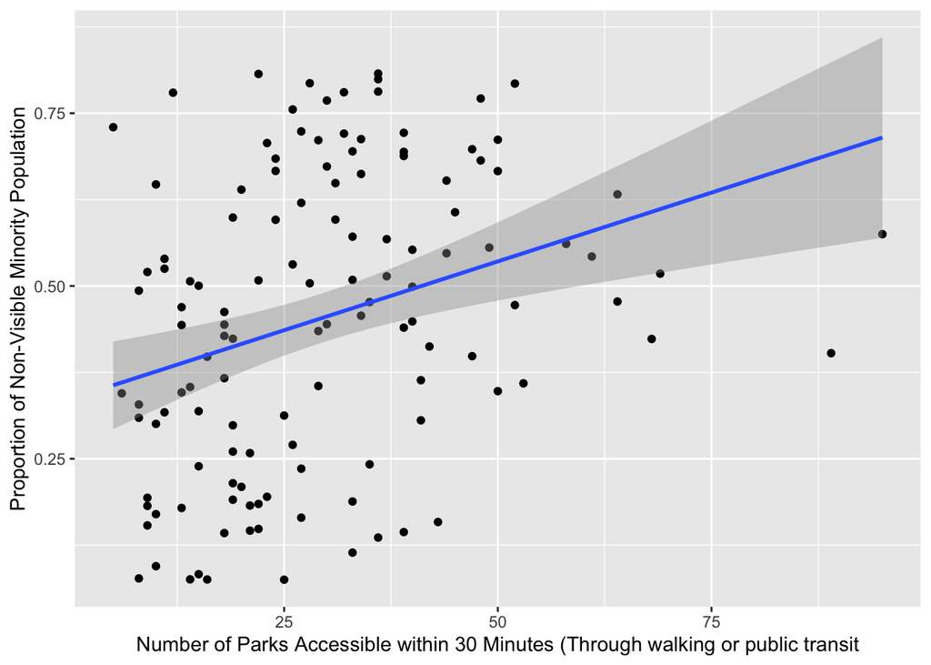

```r
ggplot(data = census_data,
       aes(x = accessibility,
           y = Proportion_nonvisible_minority))+
  geom_point() +
  geom_smooth(formula = y ~ x,
              method = "lm") +
  ylab("Proportion of Non-Visible Minority Population") +
  xlab("Number of Parks Accessible within 30 Minutes (Through walking or public transit")
```

Model regressing proportion of low income population on number of accessible parks

```r
#creating a regression model of population density regressing on number of accessible parks
model_income <- lm(formula = Proportion_low_income ~ accessibility,
             data = census_data)

stargazer(model_income,
          header = FALSE,
          title = "Proportion of Low Income Population in Census Tracts regressed on Number of Parks Accessible")
```

```
##
## \begin{table}[!htbp] \centering
##   \caption{Proportion of Low Income Population in Census Tracts regressed on Number of Parks Accessible}
##   \label{}
## \begin{tabular}{@{\extracolsep{5pt}}lc}
## \\[-1.8ex]\hline
## \hline \\[-1.8ex]
##  & \multicolumn{1}{c}{\textit{Dependent variable:}} \\
## \cline{2-2}
## \\[-1.8ex] & Proportion\_low\_income \\
## \hline \\[-1.8ex]
##  accessibility & $-$0.0004$^{*}$ \\
##   & (0.0002) \\
##   & \\
##  Constant & 0.993$^{***}$ \\
##   & (0.008) \\
##   & \\
## \hline \\[-1.8ex]
## Observations & 127 \\
## R$^{2}$ & 0.028 \\
## Adjusted R$^{2}$ & 0.020 \\
## Residual Std. Error & 0.041 (df = 125) \\
## F Statistic & 3.571$^{*}$ (df = 1; 125) \\
## \hline
## \hline \\[-1.8ex]
## \textit{Note:}  & \multicolumn{1}{r}{$^{*}$p$<$0.1; $^{**}$p$<$0.05; $^{***}$p$<$0.01} \\
## \end{tabular}
## \end{table}
```

```r
summary(model_income)
```

```
##
## Call:
## lm(formula = Proportion_low_income ~ accessibility, data = census_data)
##
## Residuals:
##       Min        1Q    Median        3Q       Max
## -0.304258 -0.001073  0.011271  0.017072  0.032010
##
## Coefficients:
##                 Estimate Std. Error t value Pr(>|t|)
## (Intercept)    0.9933794  0.0075109  132.26   <2e-16 ***
## accessibility -0.0004199  0.0002222   -1.89   0.0611 .
## ---
## Signif. codes:  0 '***' 0.001 '**' 0.01 '*' 0.05 '.' 0.1 ' ' 1
##
## Residual standard error: 0.04149 on 125 degrees of freedom
## Multiple R-squared:  0.02777,    Adjusted R-squared:  0.01999
## F-statistic: 3.571 on 1 and 125 DF,  p-value: 0.06112
```

Scatterplot of proportion of low income population vs number of accessible parks

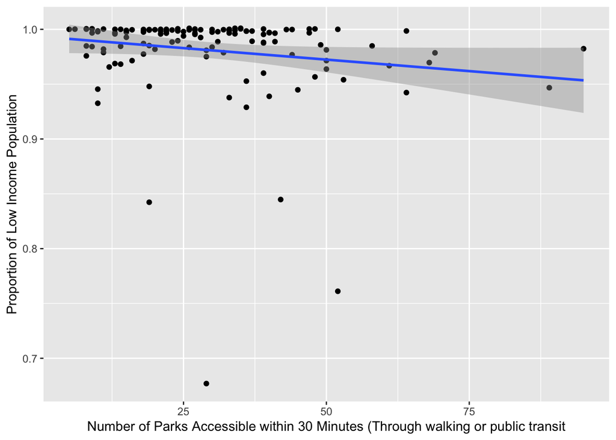

```r
ggplot(data = census_data,
       aes(x = accessibility,
           y = Proportion_low_income))+
  geom_point() +
  geom_smooth(formula = y ~ x,
              method = "lm") +
  ylab("Proportion of Low Income Population") +
  xlab("Number of Parks Accessible within 30 Minutes (Through walking or public transit")
```